## Tarea 3

Programa Experto en Inteligencia Artificial con Python  
ML2003 - Métodos Supervisados  
Estudiante: Natalia Bonilla Villalobos.  
**Métodos de Consenso y Potenciación**

# Menú

```python
import numpy as np
import pandas as pd
import seaborn as sns
import matplotlib.pyplot as plt
from matplotlib import colors as mcolors
from sklearn.metrics import confusion_matrix, classification_report, accuracy_score
from sklearn.model_selection import train_test_split
from sklearn.pipeline import Pipeline
from sklearn.compose import ColumnTransformer
from sklearn.preprocessing import OneHotEncoder, StandardScaler

from sklearn.neighbors import KNeighborsClassifier
from sklearn.tree import DecisionTreeClassifier
from sklearn.tree import plot_tree
from sklearn.tree import export_text

from sklearn.ensemble import RandomForestClassifier
from sklearn.ensemble import AdaBoostClassifier
from sklearn.ensemble import GradientBoostingClassifier
from sklearn.preprocessing import LabelEncoder
from xgboost import XGBClassifier
```

# Ejercicio 1

[50 puntos] En este ejercicio se usará la tabla de datos `students_dropout.csv`. Este conjunto de datos contiene datos de una institución de educación superior sobre diversas variables relacionadas con los estudiantes de pregrado, para investigar el impacto de estos factores en la deserción de los estudiantes y el éxito académico. La tabla contiene 3630 filas y 13 columnas, las cuales se explican a continuación.

- `marital_status`: Estado Civil. (Categórica)
- `daytime_evening_attendance`: Si el estudiante asiste a clases durante el día o la noche. (Categórica)
- `educational_special_needs`: Si el estudiante tiene alguna necesidad educativa especial. (Categórica)
- `debtor`: Si el estudiante es deudor. (Categórica)
- `tuition_fees_up_to_date`: Si las tasas de matrícula del estudiante están al día. (Categórica)
- `gender`: Género del estudiante. (Categórica)
- `scholarship`: Si el estudiante tiene beca. (Categórica)
- `age_at_enrollment`: Edad del estudiante al momento de la inscripción. (Numérica)
- `international`: Si el estudiante es extranjero. (Categórica)
- `unemployment_rate`: Tasa de desempleo. (Numérica)
- `inflation`: Tasa de inación. (Numérica)
- `gdp`: PIB per cápita. (Numérica)
- `target`: Indica si el estudiante se graduó o abandonó. (Categórica, Variable a predecir)

Realice lo siguiente:

↑ Volver al Menú

## Parte 1

- a) Cargue la tabla `students_dropout.csv` correctamente, verifique que no hayan datos nulos o ausentes.

```python
df = pd.read_csv('../../w1/h1/students_dropout.csv')
df.head(3)
```

|  | marital_status | daytime_evening_attendance | educational_special_needs | debtor | tuition_fees_up_to_date | gender | scholarship_holder | age_at_enrollment | international | unemployment_rate | inflation_rate | gdp | target |
| --- | --- | --- | --- | --- | --- | --- | --- | --- | --- | --- | --- | --- | --- |
| 0 | Single | daytime | No | No | Yes | M | No | 20 | No | 10.8 | 1.4 | 1.74 | Dropout |
| 1 | Single | daytime | No | No | No | M | No | 19 | No | 13.9 | -0.3 | 0.79 | Graduate |
| 2 | Single | daytime | No | No | No | M | No | 19 | No | 10.8 | 1.4 | 1.74 | Dropout |

```python
df.info()
```

```
<class 'pandas.core.frame.DataFrame'>
RangeIndex: 3630 entries, 0 to 3629
Data columns (total 13 columns):
 #   Column                      Non-Null Count  Dtype
---  ------                      --------------  -----
 0   marital_status              3630 non-null   object
 1   daytime_evening_attendance  3630 non-null   object
 2   educational_special_needs   3630 non-null   object
 3   debtor                      3630 non-null   object
 4   tuition_fees_up_to_date     3630 non-null   object
 5   gender                      3630 non-null   object
 6   scholarship_holder          3630 non-null   object
 7   age_at_enrollment           3630 non-null   int64
 8   international               3630 non-null   object
 9   unemployment_rate           3630 non-null   float64
 10  inflation_rate              3630 non-null   float64
 11  gdp                         3630 non-null   float64
 12  target                      3630 non-null   object
dtypes: float64(3), int64(1), object(9)
memory usage: 368.8+ KB
```

**Función creada anteriormente para transformar los datos no numéricos a category**

```python
def asCategoryType(df, asCategory=True):
    df_copy = df.copy()
    target_var = df_copy['target']
    df_copy = df_copy.drop(columns=('target'))
    if asCategory:
        num_df = df_copy.select_dtypes(include=[np.number])
        cat_df = df_copy.select_dtypes(exclude=[np.number])

    if not cat_df.empty:
        for i in cat_df:
            cat_df[i] = cat_df[i].astype('category')
            df_copy = pd.concat([num_df, cat_df, target_var], axis=1)
    else:
        df_copy = pd.concat([num_df, cat_df], axis=1)

    return df_copy

df_w_category = asCategoryType(df)
df_w_category.info()
```

```
<class 'pandas.core.frame.DataFrame'>
RangeIndex: 3630 entries, 0 to 3629
Data columns (total 13 columns):
 #   Column                      Non-Null Count  Dtype
---  ------                      --------------  -----
 0   age_at_enrollment           3630 non-null   int64
 1   unemployment_rate           3630 non-null   float64
 2   inflation_rate              3630 non-null   float64
 3   gdp                         3630 non-null   float64
 4   marital_status              3630 non-null   category
 5   daytime_evening_attendance  3630 non-null   category
 6   educational_special_needs   3630 non-null   category
 7   debtor                      3630 non-null   category
 8   tuition_fees_up_to_date     3630 non-null   category
 9   gender                      3630 non-null   category
 10  scholarship_holder          3630 non-null   category
 11  international               3630 non-null   category
 12  target                      3630 non-null   object
dtypes: category(8), float64(3), int64(1), object(1)
memory usage: 171.3+ KB
```

## Parte 2

- b) Use `Bosques Aleatorios`, `ADABoosting`, `GradientBoosting` y `XGBoosting` en **Python** para generar modelos predictivos para la tabla datos `students_dropout.csv` usando el 80% de los datos para la tabla aprendizaje y un 20% para la tabla testing. Haga los gráficos de evolución del error para calibrar el número de árboles en cada modelo.

### **División Train-Test**

```python
X = df_w_category.drop(columns=['target'])
X.head(3)
```

|  | age_at_enrollment | unemployment_rate | inflation_rate | gdp | marital_status | daytime_evening_attendance | educational_special_needs | debtor | tuition_fees_up_to_date | gender | scholarship_holder | international |
| --- | --- | --- | --- | --- | --- | --- | --- | --- | --- | --- | --- | --- |
| 0 | 20 | 10.8 | 1.4 | 1.74 | Single | daytime | No | No | Yes | M | No | No |
| 1 | 19 | 13.9 | -0.3 | 0.79 | Single | daytime | No | No | No | M | No | No |
| 2 | 19 | 10.8 | 1.4 | 1.74 | Single | daytime | No | No | No | M | No | No |

```python
y = df_w_category['target']
y[0:6]
```

```
0     Dropout
1    Graduate
2     Dropout
3    Graduate
4    Graduate
5    Graduate
Name: target, dtype: object
```

**Train 80% - Test 20%**

```python
X_train, X_test, y_train, y_test = train_test_split(X, y, train_size=0.80)
```

### **Preprocesamiento**

```python
var_categoricas = 'marital_status', 'daytime_evening_attendance', 'educational_special_needs', 'debtor', 'tuition_fees_up_to_date', 'gender', 'scholarship_holder', 'international'
var_numericas = 'age_at_enrollment', 'unemployment_rate', 'inflation_rate', 'gdp'

preprocesamiento = ColumnTransformer(
  transformers=[
    # ('cat', OneHotEncoder(), ['marital_status', 'daytime_evening_attendance', 'educational_special_needs', 'debtor', 'tuition_fees_up_to_date', 'gender', 'scholarship_holder', 'international']),
    ('num', StandardScaler(), var_numericas)
  ]
)
```

### **Modelado RandomForest**

```python
modelo_rf = Pipeline(steps=[
    ('preprocesador', preprocesamiento),
    ('clasificador', RandomForestClassifier(n_estimators = 20, max_features = 'sqrt', criterion = "gini", max_depth=15))
])

modelo_rf.fit(X_train, y_train)
```

```
Pipeline(steps=[('preprocesador',
                 ColumnTransformer(transformers=[('num', StandardScaler(),
                                                  ('age_at_enrollment',
                                                   'unemployment_rate',
                                                   'inflation_rate',
                                                   'gdp'))])),
                ('clasificador',
                 RandomForestClassifier(max_depth=15, n_estimators=20))])
```

**Predecir**

```python
pred_rf = modelo_rf.predict(X_test)
pred_rf[0:10] # mostrar sololos primeros 10
```

```
array(['Dropout', 'Graduate', 'Graduate', 'Dropout', 'Dropout',
       'Graduate', 'Graduate', 'Graduate', 'Graduate', 'Graduate'],
      dtype=object)
```

### **Evaluación**

```python
labels = ["Graduate", "Dropout"]
MC_rf = confusion_matrix(y_test, pred_rf, labels=labels)
MC_rf
```

```
array([[388,  75],
       [157, 106]])
```

```python
def indices_general(MC, nombres = None):
    precision_global = np.sum(MC.diagonal()) / np.sum(MC)
    error_global     = 1 - precision_global
    precision_categoria  = pd.DataFrame(MC.diagonal()/np.sum(MC,axis = 1)).T
    if nombres!=None:
        precision_categoria.columns = nombres

    dictionary = {
        "Matriz de Confusión":MC,
        "Precisión Global": precision_global,
        "Error Global": error_global,
        "Precisión por categoría": precision_categoria
        }

    return dictionary

indices = indices_general(MC_rf, labels)
indices
```

```
{'Matriz de Confusión': array([[388,  75],
        [157, 106]]),
 'Precisión Global': np.float64(0.6804407713498623),
 'Error Global': np.float64(0.31955922865013775),
 'Precisión por categoría':    Graduate   Dropout
 0  0.838013  0.403042}
```

```python
def clasification(matriz_confusion):
    VN = matriz_confusion[0][0]
    FP = matriz_confusion[0][1]
    FN = matriz_confusion[1][0]
    VP = matriz_confusion[1][1]

    precision_global = (VN+VP)/(VN+FP+FN+VP)
    error_global = 1 - precision_global
    precision_positiva = VP/(FN+VP)
    precision_negativa = VN/(VN+FP)

    diccionario = {'precision_global':precision_global,
                    'error_global': error_global,
                    'precision_positiva_Dropout': precision_positiva,
                    'precision_negativa_Graduate': precision_negativa}

    return diccionario

rf_metrics = clasification(MC_rf) # Guarda un diccionario
rf_metrics_df = pd.DataFrame(list(rf_metrics.items()), columns=['Metrics', 'Value'])
rf_metrics_df['Model'] = 'RandomForest'
rf_metrics_df
```

|  | Metrics | Value | Model |
| --- | --- | --- | --- |
| 0 | precision_global | 0.680441 | RandomForest |
| 1 | error_global | 0.319559 | RandomForest |
| 2 | precision_positiva_Dropout | 0.403042 | RandomForest |
| 3 | precision_negativa_Graduate | 0.838013 | RandomForest |

### **Evolución del Error**

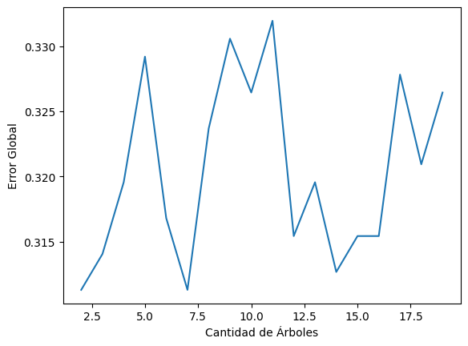

```python
ks = list(range(2, 20))
errores = []

for k in ks:
  modelo_k = Pipeline(steps=[
    ('preprocesador', preprocesamiento),
    ('clasificador', RandomForestClassifier(n_estimators = k))
  ])
  no_print = modelo_k.fit(X_train, y_train)
  pred = modelo_k.predict(X_test)
  MC = confusion_matrix(y_test, pred, labels=labels)
  indices = indices_general(MC, labels)
  errores.append(indices["Error Global"])

fig, ax = plt.subplots()
no_print = ax.plot(ks, errores)
no_print = ax.set_xlabel("Cantidad de Árboles")
no_print = ax.set_ylabel("Error Global")
plt.show()
```

### **Modelado ADABoosting**

```python
arbol = DecisionTreeClassifier(max_depth=15)
modelo_ab = Pipeline(steps=[
    ('preprocesador', preprocesamiento),
    ('clasificador', AdaBoostClassifier(n_estimators = 20, learning_rate = 1.0, estimator = arbol))
])

modelo_ab.fit(X_train, y_train)
```

```
Pipeline(steps=[('preprocesador',
                 ColumnTransformer(transformers=[('num', StandardScaler(),
                                                  ('age_at_enrollment',
                                                   'unemployment_rate',
                                                   'inflation_rate',
                                                   'gdp'))])),
                ('clasificador',
                 AdaBoostClassifier(estimator=DecisionTreeClassifier(max_depth=15),
                                    n_estimators=20))])
```

```python
pred_ab = modelo_ab.predict(X_test)
pred_ab[0:10] # mostrar sololos primeros 10
```

```
array(['Dropout', 'Graduate', 'Graduate', 'Dropout', 'Dropout',
       'Graduate', 'Graduate', 'Graduate', 'Graduate', 'Graduate'],
      dtype=object)
```

### **Evaluación**

```python
MC_ab = confusion_matrix(y_test, pred_ab, labels=labels)
MC_ab
```

```
array([[385,  78],
       [154, 109]])
```

```python
ab_metrics = clasification(MC_ab) # Guarda un diccionario
ab_metrics_df = pd.DataFrame(list(ab_metrics.items()), columns=['Metrics', 'Value'])
ab_metrics_df['Model'] = 'AdaBoostClassifier'
ab_metrics_df
```

|  | Metrics | Value | Model |
| --- | --- | --- | --- |
| 0 | precision_global | 0.680441 | AdaBoostClassifier |
| 1 | error_global | 0.319559 | AdaBoostClassifier |
| 2 | precision_positiva_Dropout | 0.414449 | AdaBoostClassifier |
| 3 | precision_negativa_Graduate | 0.831533 | AdaBoostClassifier |

### **Evolución del Error**

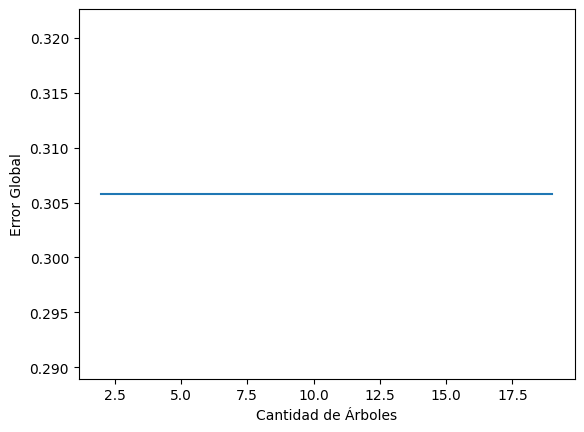

```python
errores_ab = []

for k in ks:
  modelo_k = Pipeline(steps=[
    ('preprocesador', preprocesamiento),
    ('clasificador', AdaBoostClassifier(n_estimators = k))
  ])
  no_print = modelo_k.fit(X_train, y_train)
  pred = modelo_k.predict(X_test)
  MC = confusion_matrix(y_test, pred, labels=labels)
  indices = indices_general(MC, labels)
  errores_ab.append(indices["Error Global"])

fig, ax = plt.subplots()
no_print = ax.plot(ks, errores_ab)
no_print = ax.set_xlabel("Cantidad de Árboles")
no_print = ax.set_ylabel("Error Global")
plt.show()
```

### **Modelado GradientBoosting**

```python
modelo_gb = Pipeline(steps=[
    ('preprocesador', preprocesamiento),
    ('clasificador', GradientBoostingClassifier(n_estimators = 20, learning_rate = 1.0, max_features = 'sqrt', max_depth = 15))
])

modelo_gb.fit(X_train, y_train)
```

```
Pipeline(steps=[('preprocesador',
                 ColumnTransformer(transformers=[('num', StandardScaler(),
                                                  ('age_at_enrollment',
                                                   'unemployment_rate',
                                                   'inflation_rate',
                                                   'gdp'))])),
                ('clasificador',
                 GradientBoostingClassifier(learning_rate=1.0, max_depth=15,
                                            max_features='sqrt',
                                            n_estimators=20))])
```

```python
pred_gb = modelo_gb.predict(X_test)
pred_gb[0:10]
```

```
array(['Dropout', 'Graduate', 'Graduate', 'Dropout', 'Dropout',
       'Graduate', 'Graduate', 'Graduate', 'Graduate', 'Graduate'],
      dtype=object)
```

### **Evaluación**

```python
MC_gb = confusion_matrix(y_test, pred_gb, labels=labels)
MC_gb
```

```
array([[385,  78],
       [150, 113]])
```

```python
gb_metrics = clasification(MC_gb) # Guarda un diccionario
gb_metrics_df = pd.DataFrame(list(gb_metrics.items()), columns=['Metrics', 'Value'])
gb_metrics_df['Model'] = 'GradientBoosting'
gb_metrics_df
```

|  | Metrics | Value | Model |
| --- | --- | --- | --- |
| 0 | precision_global | 0.685950 | GradientBoosting |
| 1 | error_global | 0.314050 | GradientBoosting |
| 2 | precision_positiva_Dropout | 0.429658 | GradientBoosting |
| 3 | precision_negativa_Graduate | 0.831533 | GradientBoosting |

### **Evolución del Error**

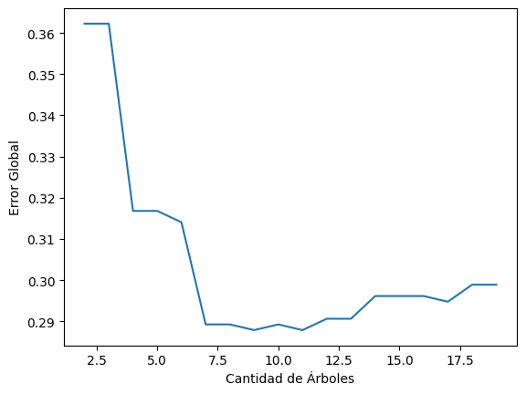

```python
errores_gb = []

for k in ks:
  modelo_k = Pipeline(steps=[
    ('preprocesador', preprocesamiento),
    ('clasificador', GradientBoostingClassifier(n_estimators = k))
  ])
  no_print = modelo_k.fit(X_train, y_train)
  pred = modelo_k.predict(X_test)
  MC = confusion_matrix(y_test, pred, labels=labels)
  indices = indices_general(MC, labels)
  errores_gb.append(indices["Error Global"])

fig, ax = plt.subplots()
no_print = ax.plot(ks, errores_gb)
no_print = ax.set_xlabel("Cantidad de Árboles")
no_print = ax.set_ylabel("Error Global")
plt.show()
```

### **Modelado XGBoosting**

#### **División Train-Test con `y` codificado**

```python
codificacion = LabelEncoder()
y = df_w_category['target']
y = codificacion.fit_transform(y)
y[0:6]
```

```
array([0, 1, 0, 1, 1, 1])
```

```python
X_train, X_test, y_train, y_test = train_test_split(X, y, train_size=0.80)
```

```python
modelo_xb = Pipeline(steps=[
    ('preprocesador', preprocesamiento),
    ('clasificador', XGBClassifier(n_estimators = 20, learning_rate = 1.0, max_depth = 15))
])
modelo_xb.fit(X_train, y_train)
```

```
Pipeline(steps=[('preprocesador',
                 ColumnTransformer(transformers=[('num', StandardScaler(),
                                                  ('age_at_enrollment',
                                                   'unemployment_rate',
                                                   'inflation_rate',
                                                   'gdp'))])),
                ('clasificador',
                 XGBClassifier(base_score=None, booster=None, callbacks=None,
                               colsample_bylevel=None, colsample_bynode=None,
                               colsample_bytree=None, device=None,
                               early_stopping_rounds=None,
                               enable_categ...
                               feature_types=None, feature_weights=None,
                               gamma=None, grow_policy=None,
                               importance_type=None,
                               interaction_constraints=None, learning_rate=1.0,
                               max_bin=None, max_cat_threshold=None,
                               max_cat_to_onehot=None, max_delta_step=None,
                               max_depth=15, max_leaves=None,
                               min_child_weight=None, missing=nan,
                               monotone_constraints=None, multi_strategy=None,
                               n_estimators=20, n_jobs=None,
                               num_parallel_tree=None, ...))])
```

```python
pred_xb = modelo_xb.predict(X_test)
pred_xb[0:10]
```

```
array([1, 1, 1, 1, 1, 1, 1, 1, 1, 1])
```

### **Evaluación**

```python
MC_xb = confusion_matrix(y_test, pred_xb)
MC_xb
```

```
array([[121, 174],
       [ 79, 352]])
```

```python
indices_xb = indices_general(MC_xb, codificacion.classes_.tolist())
for k in indices_xb:
  print("\n%s:\n%s"%(k,str(indices_xb[k])))
```

```
Matriz de Confusión:
[[121 174]
 [ 79 352]]

Precisión Global:
0.6515151515151515

Error Global:
0.3484848484848485

Precisión por categoría:
    Dropout  Graduate
0  0.410169  0.816705
```

```python
xb_metrics = clasification(MC_xb) # Guarda un diccionario
xb_metrics_df = pd.DataFrame(list(xb_metrics.items()), columns=['Metrics', 'Value'])
xb_metrics_df['Model'] = 'XGBoosting'
xb_metrics_df
```

[output not shown]

### **Evolución del Error**

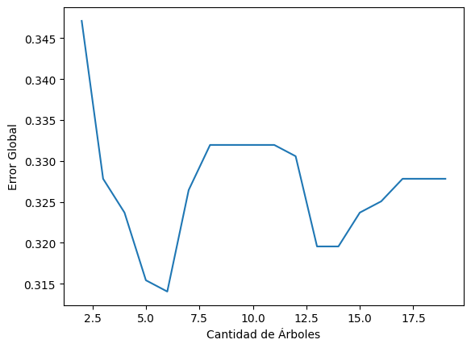

```python
labels = codificacion.classes_.tolist()
ks = list(range(2, 20))
errores_xb = []

for k in ks:
  modelo_k = Pipeline(steps=[
    ('preprocesador', preprocesamiento),
    ('clasificador', XGBClassifier(n_estimators = k))
  ])
  no_print = modelo_k.fit(X_train, y_train)
  pred = modelo_k.predict(X_test)
  MC = confusion_matrix(y_test, pred)
  indices = indices_general(MC, labels)
  errores_xb.append(indices["Error Global"])

fig, ax = plt.subplots()
no_print = ax.plot(ks, errores_xb)
no_print = ax.set_xlabel("Cantidad de Árboles")
no_print = ax.set_ylabel("Error Global")
plt.show()
```

## Parte 4

- d) Construya un DataFrame que compare los mejores modelos construidos en los items anteriores para la tabla `students_dropout.csv`. Para esto en cada una de las filas debe aparecer un modelo predictivo y en las columnas aparezcan los Indices `Precisión Global`, `Error Global`, `Precisión Positiva (PP)` y `Precisión Negativa (PN)`. Cuál de los modelos es mejor para estos datos?

```python
all_metrics = pd.concat([rf_metrics_df,ab_metrics_df,gb_metrics_df, xb_metrics_df])
all_metrics
```

[output not shown]

```python
pivot_all_metrics = pd.pivot_table(all_metrics, index='Model', columns=['Metrics'], values='Value', fill_value=0)
pivot_all_metrics
```

[output not shown]

# Ejercicio 2

[50 puntos] La idea de este ejercicio es programar una Clase en **Python** para un nuevo método de `ConsensoPropio`, esto basado en los métodos `K-vecinos más cercanos`, `árboles de Decisión`, `Método de Potenciación (XGBoosting)` y `Método de Potenciación (ADABoosting)`, para esto realice los siguiente:

- a) Programe una Clase en **Python** denominada `ConsensoPropio` que tiene, además del constructor, al menos los siguientes métodos `fit(X train, y train, ...)` que recibe la tabla de entrenamiento y genera 4 muestras aleatorias con reemplazo (Boostraps) de los datos de aprendizaje y luego aplica en cada una de estas muestras uno de los métodos predictivos mencionados arriba. Este método debe generar un nuevo modelo predictivo que es un atributo de clase, tipo diccionario, que incluya los 4 modelos generados (todos los métodos usarán todas las variables) y las 4 de precisiones globales, respectivamente de cada modelo, que denotamos por $(PG1, PG2, ..., PG4)$, donde $0 <= PG_j <= 1$ para $j=1, 2, ..., 4$.
- b) Programe una función `predict(X test)` que recibe la tabla de testing. Luego, para predecir aplica en cada una de las filas de la tabla de testing los 4 modelos predictivos que están almacenados dentro de la Clase en el atributo incluido para este efecto; y se establece un consenso de todos los resultados. Se debe programar una fórmula en **Python** que le dé mayor importancia a los métodos con mejor precisión global.  
  Si denotamos por $Mj(h; i)$ la probabilidad que retorna el $j$-ésimo modelo en el individuo $i$-ésimo para la categoría $h$ de variable a predecir, donde $j$ varía de 1 hasta 4, $h$ varía desde 1 hasta $p=número$ de categorías de la variable a predecir e $i$ varía de 1 hasta $s=cantidad$ de individuos en la tabla de testing, esta fórmula de define como sigue:  
  $C(i)=m,$  
  donde $m$ es el valor que toma $h$ cuando se alcanza el valor máximo en la siguiente fórmula:

  $$ \max_{h=1, 2, \ldots, p} \left\{ \sum_{j=1}^{4} p_j M_j(h, i) \right\}; $$

  $$ \text{y } p_k = \frac{PG_k}{\sum_{j=1}^{4} PG_j} \quad \text{para } k=1, 2, \ldots, 4, \quad \text{note que } \sum_{j=1}^{4} p_j = 1, \quad \text{pues son pesos.} $$

  La función `predict(X test)` debe retornar un vector con las predicciones para todas las filas de la tabla de testing usando la función $C(i)$.
- c) Genere un modelo predictivo usando la Clase `ConsensoPropio` para la tabla de datos `students_dropout.csv` genere al azar una tabla de testing con un 20% de los datos y con el resto de los datos construya una tabla de aprendizaje.
- d) Calcule la precisión global, el error global y la precisión por clases. Compare los resultados con los del ejercicio anterior e interprete.

↑ Volver al Menú

## Parte 1

- a) Programe una Clase en **Python** denominada `ConsensoPropio` que tiene, además del constructor, al menos los siguientes métodos `fit(X train, y train, ...)` que recibe la tabla de entrenamiento y genera 4 muestras aleatorias con reemplazo (Boostraps) de los datos de aprendizaje y luego aplica en cada una de estas muestras uno de los métodos predictivos mencionados arriba. Este método debe generar un nuevo modelo predictivo que es un atributo de clase, tipo diccionario, que incluya los 4 modelos generados (todos los métodos usarán todas las variables) y las 4 de precisiones globales, respectivamente de cada modelo, que denotamos por $(PG1, PG2, ..., PG4)$, donde $0 <= PG_j <= 1$ para $j=1, 2, ..., 4$.

```python
class ConsensoPropio:
    def __init__(self):
        self._modelos = {}
        self._precisiones = {}
        self._label_encoder = LabelEncoder()

    def fit(self, X_train, y_train):
        n = len(X_train)

        # Convertir etiquetas para XGBoost
        y_train_encoded = self._label_encoder.fit_transform(y_train)

        preprocesamiento = ColumnTransformer(
            transformers=[
                ('num', StandardScaler(), ['age_at_enrollment', 'unemployment_rate', 'inflation_rate', 'gdp'])
            ]
        )
        arbol = DecisionTreeClassifier(max_depth=15)
        # Lista de los 4 tipos de modelos que vamos a usar
        tipos_modelos = [
            ('KNeighborsClassifier', Pipeline([
                ('preprocesador', preprocesamiento),
                ('clasificador', KNeighborsClassifier(n_neighbors=6, metric="euclidean", weights='uniform'))
            ]), y_train),  # AÑADIR y_train como tercer elemento

            ('DecisionTreeClassifier', Pipeline([
                ('preprocesador', preprocesamiento),
                ('clasificador', DecisionTreeClassifier(criterion='entropy', max_depth=3, min_samples_split=2, min_samples_leaf=2))
            ]), y_train),  # AÑADIR y_train como tercer elemento

            ('XGBoostClassifier', Pipeline([
                ('preprocesador', preprocesamiento),
                ('clasificador', XGBClassifier(n_estimators = 20, learning_rate = 1.0, max_depth = 15))
            ]), y_train_encoded),  # AÑADIR y_train_encoded como tercer elemento

            ('AdaBoostClassifier', Pipeline([
                ('preprocesador', preprocesamiento),
                ('clasificador', AdaBoostClassifier(n_estimators = 20, learning_rate = 1.0, estimator = arbol))
            ]), y_train)  # AÑADIR y_train como tercer elemento
        ]

        for i, (nombre, modelo, y_train) in enumerate(tipos_modelos, 1):
            print(f"Entrenando modelo: {nombre}")

            # 1. Generar muestra bootstrap
            indices = np.random.choice(range(n), size=n, replace=True)
            X_bootstrap = X_train.iloc[indices]

            # Usar los datos y apropiados para cada modelo
            if nombre == 'XGBoostClassifier':
                y_bootstrap = y_train[indices]  # y_train_encoded (array numpy)
            else:
                y_bootstrap = y_train.iloc[indices]  # y_train original (Series pandas)

            # 2. Entrenar el modelo
            modelo_entrenado = modelo.fit(X_bootstrap, y_bootstrap)

            # 3. Calcular precisión global
            predicciones = modelo_entrenado.predict(X_bootstrap)
            precision_global = accuracy_score(y_bootstrap, predicciones)

            # 4. Guardar modelo y precisión
            clave_modelo = f'modelo{i}'
            clave_precision = f'PG{i}'

            self._modelos[clave_modelo] = modelo_entrenado
            self._precisiones[clave_precision] = precision_global

            print(f"Precisión global {clave_precision}: {precision_global:.4f}\n")

        # print("Resumen de precisiones:")
        # for clave, precision in self._precisiones.items():
        #     print(f"  {clave}: {precision:.4f}")

    def __str__(self):
        return f"ConsensoPropio con {len(self._modelos)} modelos entrenados"
```

```python
X = df_w_category.drop(columns=['target'])
y = df_w_category['target']
X_train, X_test, y_train, y_test = train_test_split(X, y, train_size=0.80)

consenso = ConsensoPropio()
consenso.fit(X_train, y_train)

# print(f"Modelos entrenados: {list(consenso._modelos.keys())}")
# print(f"Precisiones: {consenso._precisiones}")
```

```
Entrenando modelo: KNeighborsClassifier
Precisión global PG1: 0.6543

Entrenando modelo: DecisionTreeClassifier
Precisión global PG2: 0.7039

Entrenando modelo: XGBoostClassifier
Precisión global PG3: 0.7507

Entrenando modelo: AdaBoostClassifier
Precisión global PG4: 0.7386
```

```python
#Version Manual
# n = len(X_train) # para tenener el tamaño de la muestra
# indices_bootstrap = np.random.choice(range(n), size=n, replace=True) # Escoje aleatoreamente según el rango del tamaño de la muestra, con un size igual al tamaño de la muestra
# # print(f"Muestra de X_train size={len(indices_bootstrap)}:{indices_bootstrap[0:25]}")
# # Usar estos índices para crear la muestra bootstrap
# X_bootstrap = X_train.iloc[indices_bootstrap]  # Datos de entrenamiento bootstrap
# y_bootstrap = y_train.iloc[indices_bootstrap]  # Etiquetas bootstrap

# preprocesamiento = ColumnTransformer(
#   transformers=[
#     # ('cat', OneHotEncoder(), ['marital_status', 'daytime_evening_attendance', 'educational_special_needs', 'debtor', 'tuition_fees_up_to_date', 'gender', 'scholarship_holder', 'international']),
#     ('num', StandardScaler(), var_numericas)
#   ]
# )

# modelo = Pipeline(steps=[
#     ('preprocesador', preprocesamiento),
#     ('clasificador', KNeighborsClassifier(n_neighbors=6, metric="euclidean", weights='uniform'))
# ])

# modelo.fit(X_bootstrap, y_bootstrap)

# pred = modelo.predict(X_test)
# # pred[0:10] # mostrar sololos primeros 10

# # labels = ["Graduate", "Dropout"]
# MC = confusion_matrix(y_test, pred, labels=labels)
# print(f"Matriz de confucion:\n{MC}")

# indices = indices_general(MC, labels)
# indices

# rf_metrics = clasification(MC) # Guarda un diccionario
# rf_metrics_df = pd.DataFrame(list(rf_metrics.items()), columns=['Metrics', 'Value'])
# rf_metrics_df['Model'] = 'RandomForest'
# rf_metrics_df
```

## Parte 2

- b) Programe una función `predict(X_test)` que recibe la tabla de testing. Luego, para predecir aplica en cada una de las filas de la tabla de testing los 4 modelos predictivos que están almacenados dentro de la Clase en el atributo incluido para este efecto; y se establece un consenso de todos los resultados. Se debe programar una fórmula en **Python** que le dé mayor importancia a los métodos con mejor precisión global.  
  Si denotamos por $Mj(h; i)$ la probabilidad que retorna el $j$-ésimo modelo en el individuo $i$-ésimo para la categoría $h$ de variable a predecir, donde $j$ varía de 1 hasta 4, $h$ varía desde 1 hasta $p=número$ de categorías de la variable a predecir e $i$ varía de 1 hasta $s=cantidad$ de individuos en la tabla de testing, esta fórmula de define como sigue:  
  $C(i)=m,$  
  donde $m$ es el valor que toma $h$ cuando se alcanza el valor máximo en la siguiente fórmula:

  $$ \max_{h=1, 2, \ldots, p} \left\{ \sum_{j=1}^{4} p_j M_j(h, i) \right\}; $$

  $$ \text{y } p_k = \frac{PG_k}{\sum_{j=1}^{4} PG_j} \quad \text{para } k=1, 2, \ldots, 4, \quad \text{note que } \sum_{j=1}^{4} p_j = 1, \quad \text{pues son pesos.} $$

  La función `predict(X test)` debe retornar un vector con las predicciones para todas las filas de la tabla de testing usando la función $C(i)$.

```python
class ConsensoPropio:
#constructor
    def __init__(self):
        self._modelos = {}
        self._precisiones = {}
        self._label_encoder = LabelEncoder()

    def fit(self, X_train, y_train):
        n = len(X_train)

        # Convertir etiquetas ['target'] para XGBoost
        y_train_encoded = self._label_encoder.fit_transform(y_train)

        preprocesamiento = ColumnTransformer(
            transformers=[
                # ('cat', OneHotEncoder(), ['marital_status', 'daytime_evening_attendance', 'educational_special_needs', 'debtor', 'tuition_fees_up_to_date', 'gender', 'scholarship_holder', 'international']),
                ('num', StandardScaler(), ['age_at_enrollment', 'unemployment_rate', 'inflation_rate', 'gdp'])
            ]
        )

        # Lista de los modelos que vamos a usar
        # Parametros según metodos anteriores
        arbol = DecisionTreeClassifier(max_depth=15)
        tipos_modelos = [
            ('KNeighborsClassifier', Pipeline([
                ('preprocesador', preprocesamiento),
                ('clasificador', KNeighborsClassifier(n_neighbors=6, metric="euclidean", weights='uniform'))
            ]), y_train),

            ('DecisionTreeClassifier', Pipeline([
                ('preprocesador', preprocesamiento),
                ('clasificador', DecisionTreeClassifier(criterion='entropy', max_depth=3, min_samples_split=2, min_samples_leaf=2))
            ]), y_train),

            ('XGBoostClassifier', Pipeline([
                ('preprocesador', preprocesamiento),
                ('clasificador', XGBClassifier(n_estimators = 20, learning_rate = 1.0, max_depth = 15))
            ]), y_train_encoded),

            ('AdaBoostClassifier', Pipeline([
                ('preprocesador', preprocesamiento),
                ('clasificador', AdaBoostClassifier(n_estimators = 20, learning_rate = 1.0, estimator = arbol))
            ]), y_train)
        ]

        # nombre del modelo, tipo de modelo y el y_train este cambia para XGBoost
        for i, (nombre, modelo, y_train) in enumerate(tipos_modelos, 1):
            print(f"Entrenando modelo: {nombre}")

            # Muestra bootstrap
            indices = np.random.choice(range(n), size=n, replace=True)
            X_bootstrap = X_train.iloc[indices]

            if nombre == 'XGBoostClassifier':
                y_bootstrap = y_train[indices]  # y_train_encoded
            else:
                y_bootstrap = y_train.iloc[indices]  # y_train original

            # Entrenando el modelo
            modelo_entrenado = modelo.fit(X_bootstrap, y_bootstrap)

            # Calculo de precisión global
            predicciones = modelo_entrenado.predict(X_bootstrap)
            precision_global = accuracy_score(y_bootstrap, predicciones)

            # guardando modelo y precisión segun el modelo
            clave_modelo = f'modelo{i}'
            clave_precision = f'PG{i}'

            self._modelos[clave_modelo] = modelo_entrenado
            self._precisiones[clave_precision] = precision_global

            print(f"Precisión global {clave_precision}: {precision_global:.4f}\n")

    def predict(self, X_test):
    # Calculando los pesos
        suma_precisiones = sum(self._precisiones.values())
        pesos = {}
        for i in range(1, 5):
            clave_precision = f'PG{i}'
            pesos[clave_precision] = self._precisiones[clave_precision] / suma_precisiones

        # Obtener las probabilidades de cada modelo para todo X_test
        probabilidades_modelos = {}

        for i in range(1, 5):
            clave_modelo = f'modelo{i}'
            modelo = self._modelos[clave_modelo]

            # Para TODOS los modelos obtener probabilidades
            probas = modelo.predict_proba(X_test)
            probabilidades_modelos[clave_modelo] = probas

        # Para cada fila en X_test, aplicar la fórmula de consenso
        predicciones_finales = []
        n_filas = len(X_test)

        for i in range(n_filas):
            # Diccionario para acumular lo ponderados por clase
            suma_ponderada_clases = {}

            # Para cada clase, calcular la suma ponderada
            for clase in range(len(self._label_encoder.classes_)):
                suma_clase = 0.0

                # Sumar las contribuciones de los 4 modelos
                for j in range(1, 5):
                    clave_modelo = f'modelo{j}'
                    clave_precision = f'PG{j}'

                    proba_modelo = probabilidades_modelos[clave_modelo][i][clase]
                    peso_modelo = pesos[clave_precision]

                    suma_clase += peso_modelo * proba_modelo

                suma_ponderada_clases[clase] = suma_clase

            # Encontrar la clase con la suma máxima
            clase_ganadora = max(suma_ponderada_clases, key=suma_ponderada_clases.get)

            # convertir target para que no haya problemas en comparaciones
            prediccion_final = self._label_encoder.inverse_transform([clase_ganadora])[0]
            predicciones_finales.append(prediccion_final)

        return np.array(predicciones_finales)


    def precision_global(self, X_test, y_test):
        y_pred = self.predict(X_test)
        return accuracy_score(y_test, y_pred)

    def error_global(self, X_test, y_test):
        precision = self.precision_global(X_test, y_test)
        return 1 - precision

    def precision_por_clases(self, X_test, y_test):
        y_pred = self.predict(X_test)
        return classification_report(y_test, y_pred, output_dict=True)

# print

    def __str__(self):
        return f"ConsensoPropio con {len(self._modelos)} modelos entrenados"
```

```python
# Probar predict
y_pred = consenso.predict(X_test[0:5])  # Solo 5 filas para prueba rápida

print("Predicciones para primeras 15 filas:")
for i, pred in enumerate(y_pred):
    print(f"{i}: {pred}")
```

```
Predicciones para primeras 15 filas:
0: Dropout
1: Graduate
2: Dropout
3: Graduate
4: Graduate
```

## Parte 3

- c) Genere un modelo predictivo usando la Clase `ConsensoPropio` para la tabla de datos `students_dropout.csv` genere al azar una tabla de testing con un 20% de los datos y con el resto de los datos construya una tabla de aprendizaje.

```python
X_train, X_test, y_train, y_test = train_test_split(X, y, test_size=0.20)

print(f"Tabla de training: {X_train.shape} ({(len(X_train)/len(X))*100:.1f}%)")
print(f"Tabla de testing: {X_test.shape} ({(len(X_test)/len(X))*100:.1f}%)\n")

consenso.fit(X_train, y_train)
```

```
Tabla de training: (2904, 12) (80.0%)
Tabla de testing: (726, 12) (20.0%)

Entrenando modelo: KNeighborsClassifier
Precisión global PG1: 0.7018

Entrenando modelo: DecisionTreeClassifier
Precisión global PG2: 0.6897

Entrenando modelo: XGBoostClassifier
Precisión global PG3: 0.7541

Entrenando modelo: AdaBoostClassifier
Precisión global PG4: 0.7572
```

## Parte 4

- d) Calcule la precisión global, el error global y la precisión por clases.

```python
precision_global_consenso = consenso.precision_global(X_test, y_test)
error_global_consenso = consenso.error_global(X_test, y_test)

print(f"Precisión Global Consenso: {precision_global_consenso:.4f} -> {precision_global_consenso*100:.2f}%")
print(f"Error Global Consenso:     {error_global_consenso:.4f} -> {error_global_consenso*100:.2f}%")

print(f"\nPrecisión por Clases:\n")
precision_clases = consenso.precision_por_clases(X_test, y_test)
for clase, metricas in precision_clases.items():
    if clase not in ['accuracy', 'macro avg', 'weighted avg']:
        print(f"Clase '{clase}':")
        print(f"Precisión: {metricas['precision']:.4f}")
        print(f"Recall: {metricas['recall']:.4f}\n")
```

```
Precisión Global Consenso: 0.6364 -> 63.64%
Error Global Consenso:     0.3636 -> 36.36%

Precisión por Clases:

Clase 'Dropout':
Precisión: 0.5489
Recall: 0.3582

Clase 'Graduate':
Precisión: 0.6661
Recall: 0.8131
```

Compare los resultados con los del ejercicio anterior e interprete.

```python
resultados_individuales = {}

for i in range(1, 5):
    modelo_individual = consenso._modelos[f'modelo{i}']
    y_pred_individual = modelo_individual.predict(X_test)

    if i == 3:
        y_pred_individual = consenso._label_encoder.inverse_transform(y_pred_individual)

    precision_individual = accuracy_score(y_test, y_pred_individual)
    resultados_individuales[f'Modelo {i}'] = precision_individual
    print(f"Modelo {i}: {precision_individual:.4f} -> {precision_individual*100:.2f}%")

print(f"\nConsenso Propio: {precision_global_consenso:.4f} -> {precision_global_consenso*100:.2f}%")
```

```
Modelo 1: 0.6102 -> 61.02%
Modelo 2: 0.6736 -> 67.36%
Modelo 3: 0.6364 -> 63.64%
Modelo 4: 0.6267 -> 62.67%

Consenso Propio: 0.6364 -> 63.64%
```

El mejor modelo individual es el Modelo 2, que corresponde al Modelo de Árboles ed Decisión (`TreeDecisionClassifier`) con un 67% mayor al de los otros modelos pero todos estan muy parecidos.